# Assessment

# Seasonal depression and antidepressant prescriptions

## Brrr: Cold, long and sad winter days

Coming from Peru to Scotland was not only a cultural shock but an environmental one, if you will. I had never experienced such strikingly beautiful but equally emotionally debilitating winters. In Scotland, daylight is precious despite its scarcity and temperatures above 2 degrees are to dream of. And here, is when I first heard the term ‘Seasonal depression’ being used the most at this time of the year, Autumn; whereas it’s a passing comment from a friend, a sitcom joke, or a genuine Google search during those long, dark, and cold winter days when you feel extra homesick.  
Throughout my time in Scotland I have wondered if seasonal depression is more a myth than a reality but have never quite gathered more than qualitative data in the form of conversations with friends and acquaintances. Therefore, I have decided to quantify these verbal leads through this report.

## Investigation breakdown

The research question to be explored is:

> To what extent do seasonal variations relating to daylight hours and temperature affect antidepressant prescribing rates across Scottish NHS Health Boards?

### Variables

The data time frame to be used is from March 2024 to March 2025 to assess the potential cyclicality of results and make adequate comparison between seasons.

#### Season Categorisation

**Spring**: March, April, May  
**Summer**: June, July, August  
**Autumn**: September, October, November  
**Winter**: December, January, February

#### NHS Health Board Geographical Categorisation

This categorisation has been made according to the Met Office’s territorial delineation of Scotland based on the distribution of climate measurements as available in their website.

**Northern Scotland**: NHS Highland, NHS Western Isles, NHS Orkney, NHS Shetland  
**Eastern Scotland**: NHS Borders, NHS Lothian, NHS Fife, NHS Tayside, NHS Grampian, NHS Forth Valley  
**Western Scotland**: NHS Ayrshire and Arran, NHS Dumfries and Galloway, NHS Greater Glasgow and Clyde, NHS Lanarkshire

#### Antidepressant Prescriptions

Raw data from multiple institutional websites include all medications prescribed by NHS Health Boards. To differentiate and include only Antidepressant prescriptions, only prescriptions with a BNF item code starting with **‘0403’** will be used.

This report aims to be a multi-factorial exploration of the environmental and social dimensions of antidepressant prescription rates in Scotland given that it’s analysis will focus on three distinct aspects as shown in the hypotheses.

### Hypotheses

This report puts forward an overarching hypothesis:

> **Null (*H<sub>0</sub>*)**: Antidepressant prescription rates do not have seasonal patterns.

> **Alternative (*H<sub>a</sub>*)**: Antidepressant prescription rates have seasonal patterns.

Where within *H<sub>a</sub>*, the following is proposed:

> **1a.** Prescription rates increase during shorter months with shorter daylight hours and colder temperatures (autumn and winter) and decrease during those with longer daylight hours and warmer temperature (spring and summer).

In the assumption that *H<sub>a</sub>* is true, this report proposed two further sub-hypotheses that further enrich the multi-factorial lens through which seasonal effects inlfuence prescription rates:

> > **I.** The latitude of prescribing NHS Health Boards further influences the seasonality of antidepressant prescription rates, the more northern a health board is, the heavier the impact of these seasonal patterns.

> > **II.** Areas with a higher socioeconomic deprivation index (SMID) will have a consistently higher benchmark antidepressant use regardless of season, making the impact of varying daylight hours and temperature be even greater.

## Introduction to Data

### Health Board Data

January to June 2024: https://www.opendata.nhs.scot/dataset/84393984-14e9-4b0d-a797-b288db64d088/resource/f0df380b-3f9b-4536-bb87-569e189b727a/download/hb_pitc2024_01_06-1.csv

July to December 2024: https://www.opendata.nhs.scot/dataset/84393984-14e9-4b0d-a797-b288db64d088/resource/f3b9f2e2-66c0-4310-9b8e-734781d2ed0a/download/hb_pitc2024_07_12-1.csv

January to June 2025: https://www.opendata.nhs.scot/dataset/84393984-14e9-4b0d-a797-b288db64d088/resource/9de908b3-9c28-4cc3-aa32-72350a0579d1/download/hb_pitc2025_01_06.csv

### Met Office Seasonal Data

North Scotland:  
Daylight hrs - https://www.metoffice.gov.uk/pub/data/weather/uk/climate/datasets/Sunshine/ranked/Scotland_N.txt  
Temperature - https://www.metoffice.gov.uk/pub/data/weather/uk/climate/datasets/Tmean/date/Scotland_N.txt

East Scotland:  
Daylight hrs - https://www.metoffice.gov.uk/pub/data/weather/uk/climate/datasets/Sunshine/ranked/Scotland_E.txt  
Temperature - https://www.metoffice.gov.uk/pub/data/weather/uk/climate/datasets/Tmean/date/Scotland_E.txt

West Scotland:  
Daylight hrs - https://www.metoffice.gov.uk/pub/data/weather/uk/climate/datasets/Sunshine/ranked/Scotland_W.txt  
Temperature - https://www.metoffice.gov.uk/pub/data/weather/uk/climate/datasets/Tmean/date/Scotland_W.txt

### Scottish Index of Multiple Deprivation (SMID quintiles) Data

Taken from the Public Health Scotland website:  
https://www.opendata.nhs.scot/dataset/78d41fa9-1a62-4f7b-9edb-3e8522a93378/resource/acade396-8430-4b34-895a-b3e757fa346e/download/simd2020v2_22062020.csv

### NHS Health Board Total Population Data

Also taken from the Public Health Scotland website:  
https://www.opendata.nhs.scot/dataset/e3300e98-cdd2-4f4e-a24e-06ee14fcc66c/resource/cec9341e-ccba-4c71-afe4-a614f5e97b9f/download/practice_listsizes_oct2024-open-data.csv

## Methodology

### 1. Data Wrangling and Merging

1.1 Load all the required libraries on RStudio

```r
library(tidyverse)
library(here) # for the upkeep of the directory structure
library(janitor) # for data cleaning
library(gt) # for table building
```

1.2 Load all the Health Board Data (January 2024:June 2025) into RStudio and use the `janitor` package by using the `clean_names()` function to have uniform names throughout datasets

```r
prescr_jan_june_2024 <- read_csv("https://www.opendata.nhs.scot/dataset/84393984-14e9-4b0d-a797-b288db64d088/resource/f0df380b-3f9b-4536-bb87-569e189b727a/download/hb_pitc2024_01_06-1.csv") %>%
  clean_names()
prescr_july_dec_2024 <- read_csv("https://www.opendata.nhs.scot/dataset/84393984-14e9-4b0d-a797-b288db64d088/resource/f3b9f2e2-66c0-4310-9b8e-734781d2ed0a/download/hb_pitc2024_07_12-1.csv") %>%
  clean_names()
prescr_jan_june_2025 <- read_csv("https://www.opendata.nhs.scot/dataset/84393984-14e9-4b0d-a797-b288db64d088/resource/9de908b3-9c28-4cc3-aa32-72350a0579d1/download/hb_pitc2025_01_06.csv") %>%
  clean_names()
```

1.3 Now filter out by “bnf_item_code” to keep only those prescriptions that are antidepressants (codes starting with ‘0403’) and that were prescribed within our selected time frame (March 2024 - March 2025). Make sure to maintain the following: hbt, bnf_item_description, number_of_paid_items, and paid_date_month. Repeat for all Health Board datasets.

```r
antidepr_march_june_2024 <- prescr_jan_june_2024 %>%
  filter(str_detect(bnf_item_code, "^0403")) %>%
  filter(paid_date_month != "202401" & paid_date_month != "202402") %>%
  select(c(hbt,bnf_item_code,bnf_item_description,number_of_paid_items,paid_date_month)) %>%
  group_by(hbt, paid_date_month) %>%
  summarise(number_of_items = sum(number_of_paid_items, na.rm = TRUE)) %>%
  arrange(paid_date_month)
```

[output not shown]

```r
antidepr_july_dec_2024 <- prescr_july_dec_2024 %>%
  filter(str_detect(bnf_item_code, "^0403")) %>%
  select(c(hbt,bnf_item_code,bnf_item_description,number_of_paid_items,paid_date_month)) %>%
  group_by(hbt, paid_date_month) %>%
  summarise(number_of_items = sum(number_of_paid_items, na.rm = TRUE)) %>%
  arrange(paid_date_month)
```

[output not shown]

```r
antidepr_jan_march_2025 <- prescr_jan_june_2025 %>%
  filter(str_detect(bnf_item_code, "^0403")) %>%
  filter(paid_date_month != "202504" & paid_date_month != "202505" & paid_date_month != "202506") %>%
  select(c(hbt,bnf_item_code,bnf_item_description,number_of_paid_items,paid_date_month)) %>%
  group_by(hbt, paid_date_month) %>%
  summarise(number_of_items = sum(number_of_paid_items, na.rm = TRUE)) %>%
  arrange(paid_date_month)
```

[output not shown]

1.4 Join the three antidepressant datasets to create a unified March 2024-March 2025 prescription data object. Then, create an object for seasonal categorisations and merge it with the unified object created.

```r
spr_months_202425 <- c(202403, 202404, 202405, 202503)
sum_months_202425 <- c(202406, 202407, 202408)
aut_months_202425 <- c(202409, 202410, 202411)
win_months_202425 <- c(202412, 202501, 202502)

seasons_202425 <- tibble(
  month = c(spr_months_202425, sum_months_202425, aut_months_202425, win_months_202425),
  season = c(rep("spr", length(spr_months_202425)),
             rep("sum", length(sum_months_202425)),
             rep("aut", length(aut_months_202425)),
             rep("win", length(win_months_202425))))

yearly_antidepr_data <- antidepr_march_june_2024 %>%
full_join(antidepr_july_dec_2024)
yearly_antidepr_data <- yearly_antidepr_data %>%
  full_join(antidepr_jan_march_2025) %>%
  full_join(seasons_202425, join_by(paid_date_month == month))
```

1.5 Create an object for geographical NHS Health Board names. Make each health board be geographically named to match Met Office data later on. Then, `full_join()` the dataset with the yearly_antidepr_data object created in the previous step.

```r
north_hb <- c("NHS Highland", "NHS Western Isles", "NHS Orkney", "NHS Shetland")
east_hb <- c("NHS Borders", "NHS Lothian", "NHS Fife", "NHS Tayside", "NHS Grampian", "NHS Forth Valley")
west_hb <- c("NHS Ayrshire and Arran", "NHS Dumfries and Galloway", "NHS Greater Glasgow and Clyde", "NHS Lanarkshire")


metoffice_hb_region <- tibble(
  hb_name = c(north_hb, east_hb, west_hb),
  region = c(rep("north", length(north_hb)),
             rep("east", length(east_hb)),
             rep("west", length(west_hb))))


hb_names <- read_csv("https://www.opendata.nhs.scot/dataset/9f942fdb-e59e-44f5-b534-d6e17229cc7b/resource/652ff726-e676-4a20-abda-435b98dd7bdc/download/hb14_hb19.csv") %>%
  clean_names() %>%
  full_join(metoffice_hb_region)
hbt_antidepr_yearly <- yearly_antidepr_data %>%
  full_join(hb_names, join_by(hbt == hb)) %>%
  select(-c(hb_date_archived, hb_date_archived, hb_date_enacted, country))
```

1.6 Notes at this stage:

- After the `full_join()` there are 4 rows with NA in prescription data (paid_date_month and number_or_items). Upon further investigation and a look at the object hb_names, these were shown to have had their hbt numbers archived in 2018 and 2019, making them easily removable from our data.
- There is a row with hbt ‘SB0806’ which shows NA for hb_name though has antidepressant prescription data for December 2024 only. Given the value (‘2’) is extremely low and this hbt is not on record or appears any other time, it has been decided to be excluded from the analysis.

```r
clean_hbt_antidepr_yearly <- hbt_antidepr_yearly %>%
  filter(!is.na(hb_name)) %>%
  filter(!is.na(paid_date_month))
```

1.7 Load, wrangle and organise NHS Health Board population data from the data file from October 2024. The date chosen is deliberate as October 2024 marks approximately half-way through the determined time period that this investigation is focusing on.

```r
hb_pop_oct_2024 <- read_csv("https://www.opendata.nhs.scot/dataset/e3300e98-cdd2-4f4e-a24e-06ee14fcc66c/resource/cec9341e-ccba-4c71-afe4-a614f5e97b9f/download/practice_listsizes_oct2024-open-data.csv") %>%
  clean_names()
clean_hb_population <- hb_pop_oct_2024 %>%
  select(hb, sex, all_ages) %>%
  filter(!sex %in% c("Male", "Female")) %>%
  group_by(hb) %>%
  summarise(hb_population = sum(all_ages))
```

1.8 Introduce population data for each NHS health board.

```r
antidepr_yearly_hb_pop <- clean_hbt_antidepr_yearly %>%
  full_join(clean_hb_population, join_by(hbt == hb))
```

1.9 Now let’s introduce the daylight hours data from the UK Met Office. Given the nature of the .txt files, I converted them into .csv files using Excel. These files can be found in the ‘data’ folder attached.

```r
daylight_north_scot <- read_table("data/R_north_scotland_sunshine.csv")
daylight_east_scot <- read_table("data/R_east_scotland_sunshine.csv")
daylight_west_scot <- read_table("data/R_west_scotland_sunshine.csv")
```

1.10 Upon inspection of the data, one can notice that there are specific columns for each season apart from one for each month. This report will be using the seasonal data to make the merging processes easier. Now, each daylight hours object will be cleaned and wrangled to only have March 2024-March 2025 data. The final object will be named all_seasons_daylight, which will contain all daylight hours per season per region for the March 2024-March 2025 analysis time period.

```r
# North of Scotland
winter_daylight_north_2024_25 <- daylight_north_scot %>%
  select(win,year_12) %>%
  filter(year_12 == "2024") %>%  # December 2024, January 2025, and February 2025 are wanted
  rename(year = year_12)

spr_daylight_north_2024_25 <- daylight_north_scot %>%
  select(spr,year_13) %>%
  filter(year_13 == "2024" | year_13 == "2025") %>% # March 2024, April 2024, May 2024, *and March 2025* are wanted
  rename(year = year_13)

sum_daylight_north_2024_25 <- daylight_north_scot %>%
  select(sum,year_14) %>%
  filter(year_14 == "2024") %>%  # June 2024, July 2024, and August 2024 are wanted
  rename(year = year_14)

aut_daylight_north_2024_25 <- daylight_north_scot %>%
  select(aut,year_15) %>%
  filter(year_15 == "2024") %>% # September 2024, October 2024, and November 2024 are wanted
  rename(year = year_15)

season_daylight_north_complete <- winter_daylight_north_2024_25 %>%
  full_join(spr_daylight_north_2024_25, by = "year") %>%
  full_join(sum_daylight_north_2024_25, by = "year") %>%
  full_join(aut_daylight_north_2024_25, by = "year") %>%
  relocate(win, .after = aut) %>%
  mutate(across(spr:win, as.numeric)) %>%
  pivot_longer(cols = spr:win, names_to = "season", values_to = "daylight_hrs") %>%
  arrange(year, factor(season, levels = c("spr", "sum", "aut", "win"))) %>%
  mutate(region = "north") %>%
  filter(!is.na(daylight_hrs))

# East of Scotland
winter_daylight_east_2024_25 <- daylight_east_scot %>%
  select(win,year_12) %>%
  filter(year_12 == "2024") %>%  # December 2024, January 2025, and February 2025 are wanted
  rename(year = year_12)

spr_daylight_east_2024_25 <- daylight_east_scot %>%
  select(spr,year_13) %>%
  filter(year_13 == "2024" | year_13 == "2025") %>% # March 2024, April 2024, May 2024, *and March 2025* are wanted
  rename(year = year_13)

sum_daylight_east_2024_25 <- daylight_east_scot %>%
  select(sum,year_14) %>%
  filter(year_14 == "2024") %>%  # June 2024, July 2024, and August 2024 are wanted
  rename(year = year_14)

aut_daylight_east_2024_25 <- daylight_east_scot %>%
  select(aut,year_15) %>%
  filter(year_15 == "2024") %>% # September 2024, October 2024, and November 2024 are wanted
  rename(year = year_15)

season_daylight_east_complete <- winter_daylight_east_2024_25 %>%
  full_join(spr_daylight_east_2024_25, by = "year") %>%
  full_join(sum_daylight_east_2024_25, by = "year") %>%
  full_join(aut_daylight_east_2024_25, by = "year") %>%
  relocate(win, .after = aut) %>%
mutate(across(spr:win, as.numeric)) %>%
  pivot_longer(cols = spr:win, names_to = "season", values_to = "daylight_hrs") %>%
  arrange(year, factor(season, levels = c("spr", "sum", "aut", "win"))) %>%
  mutate(region = "east") %>%
  filter(!is.na(daylight_hrs))

# West of Scotland
winter_daylight_west_2024_25 <- daylight_west_scot %>%
  select(win,year_12) %>%
  filter(year_12 == "2024") %>%  # December 2024, January 2025, and February 2025 are wanted
  rename(year = year_12)

spr_daylight_west_2024_25 <- daylight_west_scot %>%
  select(spr,year_13) %>%
  filter(year_13 == "2024" | year_13 == "2025") %>% # March 2024, April 2024, May 2024, *and March 2025* are wanted
  rename(year = year_13)

sum_daylight_west_2024_25 <- daylight_west_scot %>%
  select(sum,year_14) %>%
  filter(year_14 == "2024") %>%  # June 2024, July 2024, and August 2024 are wanted
  rename(year = year_14)

aut_daylight_west_2024_25 <- daylight_west_scot %>%
  select(aut,year_15) %>%
  filter(year_15 == "2024") %>% # September 2024, October 2024, and November 2024 are wanted
  rename(year = year_15)

season_daylight_west_complete <- winter_daylight_west_2024_25 %>%
  full_join(spr_daylight_west_2024_25, by = "year") %>%
  full_join(sum_daylight_west_2024_25, by = "year") %>%
  full_join(aut_daylight_west_2024_25, by = "year") %>%
  relocate(win, .after = aut) %>%
  mutate(across(spr:win, as.numeric)) %>%
  pivot_longer(cols = spr:win, names_to = "season", values_to = "daylight_hrs") %>%
  arrange(year, factor(season, levels = c("spr", "sum", "aut", "win"))) %>%
  mutate(region = "west") %>%
  filter(!is.na(daylight_hrs))

# Final 'season' object to be used for data merging with NHS Health Board prescription and population data
all_seasons_daylight <- season_daylight_north_complete %>%
  full_join(season_daylight_east_complete) %>%
  full_join(season_daylight_west_complete)
```

1.11 Now daylight data will be inputted into the antidepr_yearly_hb_pop object as our final data merge, where categorisation of prescription data will follow seasonal categorisation (See Season Categorisation and NHS Health Board Geographical Categorisation).

```r
antidepr_season_hb_pop <- antidepr_yearly_hb_pop %>%
  group_by(paid_date_month, region) %>%
  mutate(year = as.integer(substr(paid_date_month,1,4)),
         month = as.integer(substr(paid_date_month, 5, 6)),
         season = case_when(
           month %in% 3:5  ~ "spr",
           month %in% 6:8  ~ "sum",
           month %in% 9:11 ~ "aut",
           month %in% c(12,1,2) ~ "win"),
         season_year = if_else(month %in% c(1, 2), year - 1, year)) %>%
  full_join(all_seasons_daylight, by = c("season_year" = "year", "season", "region"))
```

### 2. Data Analysis

2.1 For prescription data standardisation, a calculation of items_per_1000_people will be made. This is because all NHS Health Boards have different populations, thus, comparing ther number_of_items solely would not provide correct conclusions.

```r
antidepr_season_hb_pop <- antidepr_season_hb_pop %>%
  mutate(items_per_1000 = (number_of_items/hb_population)*1000)
```

2.2. Clean data table to provide foundation for data visualisation and analysis.

```r
analysis_antidepr_season <- antidepr_season_hb_pop %>%
  select(hbt, paid_date_month, hb_name, season, daylight_hrs, items_per_1000, year) %>%
  group_by(region, season, paid_date_month) %>%
  summarise(av_daylight_hrs = mean(daylight_hrs), av_items_per_1000 = mean(items_per_1000)) %>%
  mutate(month = as.Date(paste0(paid_date_month, "01"), "%Y%m%d"))
```

### 3. Data Visualisation

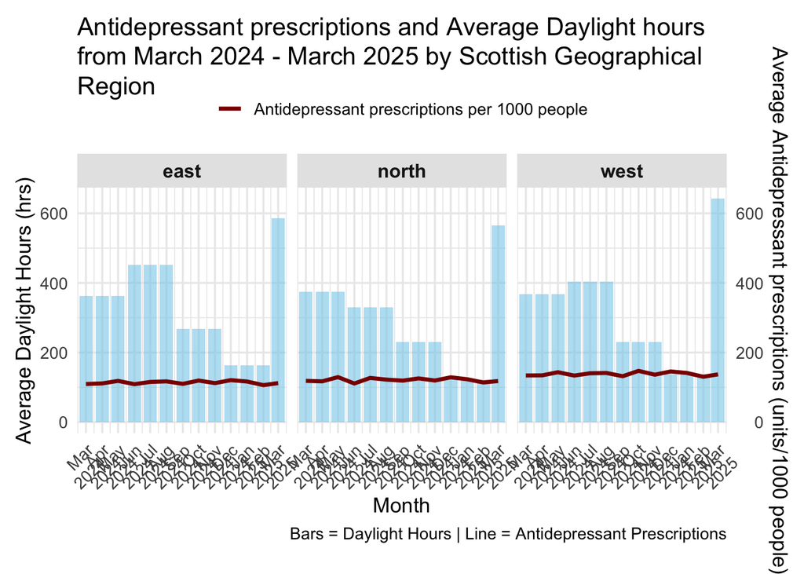

```r
library(ggplot2)
library(ggtext)

regional_analysis_composite <- analysis_antidepr_season
ggplot(analysis_antidepr_season, aes(x = month)) +
  geom_col(aes(y = av_daylight_hrs), fill = "skyblue", alpha = 0.6) +
  geom_line(
    aes(y = av_items_per_1000, color = "Antidepressant prescriptions per 1000 people"),
    size = 1.2, group = 1) +
  facet_wrap(~ region, ncol = 3, scales = "free_x") +
  scale_y_continuous(
    name = "Average Daylight Hours (hrs)",
    sec.axis = sec_axis(~ ., name = "Average Antidepressant prescriptions (units/1000 people)")) +
  scale_x_date(
    date_labels = "%b\n%Y",
    breaks = "1 month",
    expand = c(0.01, 0.01)) +
  scale_color_manual(values = c("Antidepressant prescriptions per 1000 people" = "darkred")) +
  labs(
    title = "Antidepressant prescriptions and Average Daylight hours from March 2024 - March 2025 by Scottish Geographical Region",
    x = "Month",
    caption = "Bars = Daylight Hours | Line = Antidepressant Prescriptions") +
  theme_minimal(base_size = 13) +
  theme(axis.text.x = element_text(angle = 45, hjust = 1),
    legend.position = "top",
    legend.title = element_blank(),
    strip.background = element_rect(fill = "gray90", color = NA),
    strip.text = element_text(face = "bold", size = 12),
    plot.title = element_textbox_simple(),
    plot.margin = margin(t = 20, r = 10, b = 20, l = 10, unit = "pt"))
```

```r
ggsave("regional_analysis_composite.png",width = 20, height = 20, units = "cm")

regional_analysis_composite
```

```
## # A tibble: 39 × 6
## # Groups:   region, season [12]
##    region season paid_date_month av_daylight_hrs av_items_per_1000 month
##    <chr>  <chr>            <dbl>           <dbl>             <dbl> <date>
##  1 east   aut             202409            269.              110. 2024-09-01
##  2 east   aut             202410            269.              119. 2024-10-01
##  3 east   aut             202411            269.              112. 2024-11-01
##  4 east   spr             202403            362.              109. 2024-03-01
##  5 east   spr             202404            362.              111. 2024-04-01
##  6 east   spr             202405            362.              118. 2024-05-01
##  7 east   spr             202503            586.              112. 2025-03-01
##  8 east   sum             202406            453.              109. 2024-06-01
##  9 east   sum             202407            453.              115. 2024-07-01
## 10 east   sum             202408            453.              117. 2024-08-01
## # ℹ 29 more rows
```